# Assignment2

```r
library(tidyverse)
library(sf)
library(tigris)
library(leaflet)
library(censusapi)
library(tidycensus)
```

As suggested by the textbook, we will be using the 5 year data:

```r
Sys.setenv(CENSUS_KEY="2f12411b15b1fa77c7cf26406290bde11307de91")

acs_vars_2018_5yr <-
  listCensusMetadata(
    name = "2018/acs/acs5",
    type = "variables"
  )
```

For our analysis on educational attainment by race, we will focus on Santa Clara county, FIPS code 085, simply for the reason that this is the county housing Stanford.

First, we find that in the ACS variable names we want the variables “SEX BY EDUCATIONAL ATTAINMENT FOR THE POPULATION…” which is different for each racial group. To test that we get the correct data set, we check with just group C15002A, which is for “white alone.” Note that we do not care about the sex of the individual, thus we sum over the “sex” column, leaving us with an “estimate” column and the “educattain” column:

```r
scc_educ_attain_white <-
  getCensus(
    name = "acs/acs5",
    vintage = 2018,
    region = "county:085",
    regionin = "state:06",
    vars = "group(C15002A)"
  ) %>%
  select(!c(GEO_ID,state,NAME) & !ends_with(c("EA","MA","M"))) %>%
    pivot_longer(
    ends_with("E"),
    names_to = "variable",
    values_to = "estimate"
  ) %>%
    left_join(
    acs_vars_2018_5yr %>%
      select(name, label),
    by = c("variable" = "name")
  ) %>%
  select(-variable,-county) %>%
  separate(
    label,
    into = c(NA,NA,"sex","educattain"),
    sep = "!!"
  ) %>%
  filter(!is.na(sex),!is.na(educattain)) %>%
  group_by(educattain) %>%
  summarize(
    estimate = sum(estimate)
  )
```

We see that the above returns the expected output for “white only.” So now, we follow the textbook’s outline of generalizing this to create an aggregate dataframe using the map_dfr method shown in the textbook:

```r
census_race_labels <-
  c(
    "White Alone",
    "Black or African American",
    "American Indian and Alaska Native Alone",
    "Asian Alone",
    "Native Hawaiian and Other Pacific Islander Alone)",
    "Some Other Race Alone",
    "Two or More Races"
  )

scc_educ_attain_race <-
  1:7 %>%
  map_dfr(function(x){
    getCensus(
    name = "acs/acs5",
    vintage = 2018,
    region = "county:085",
    regionin = "state:06",
    vars = paste0("group(C15002",LETTERS[x],")")
  ) %>%
  select(!c(GEO_ID,state,NAME) & !ends_with(c("EA","MA","M"))) %>%
    pivot_longer(
    ends_with("E"),
    names_to = "variable",
    values_to = "estimate"
  ) %>%
    left_join(
    acs_vars_2018_5yr %>%
      select(name, label),
    by = c("variable" = "name")
  ) %>%
  select(-variable,-county) %>%
  separate(
    label,
    into = c(NA,NA,"sex","educattain"),
    sep = "!!"
  ) %>%
  filter(!is.na(sex),!is.na(educattain)) %>%
  group_by(educattain) %>%
  summarize(
    estimate = sum(estimate)
    ) %>%
  mutate(race = census_race_labels[x])
  }
  )
```

Now we can begin to create the stacked and filled plots visualizing the dataframe:

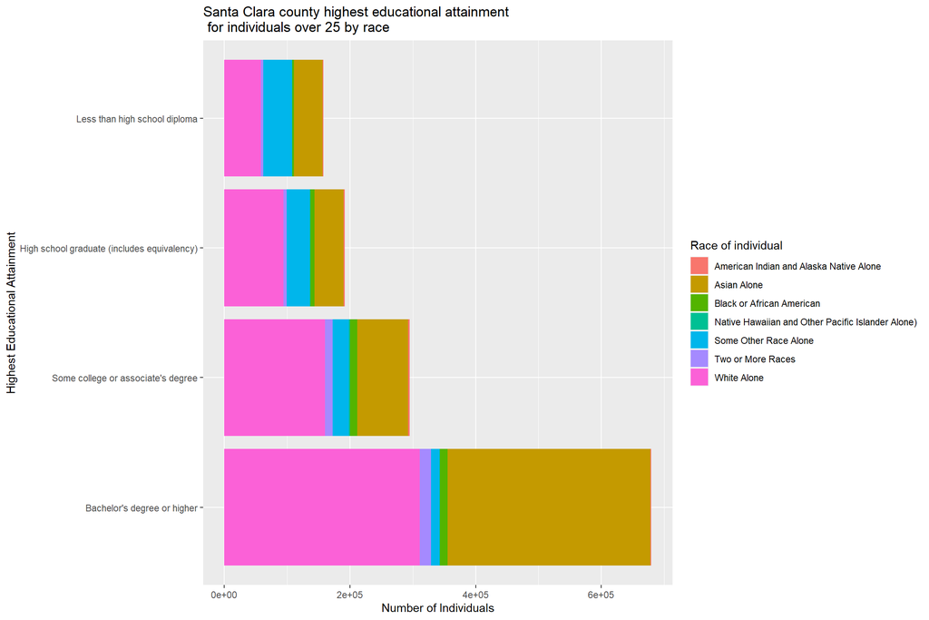

```r
scc_educ_attain_race %>%
  ggplot() +
  geom_bar(
    aes(
      x = educattain %>% factor(levels = rev(c("Less than high school diploma","High school graduate (includes equivalency)","Some college or associate's degree","Bachelor's degree or higher"))),
      y = estimate,
      fill = race
    ),
    stat = "identity",
    position = "stack"
  ) +
  labs(
    x = "Highest Educational Attainment",
    y = "Number of Individuals",
    title = "Santa Clara county highest educational attainment \n for individuals over 25 by race",
    fill ="Race of individual"
  ) +
  coord_flip()
```

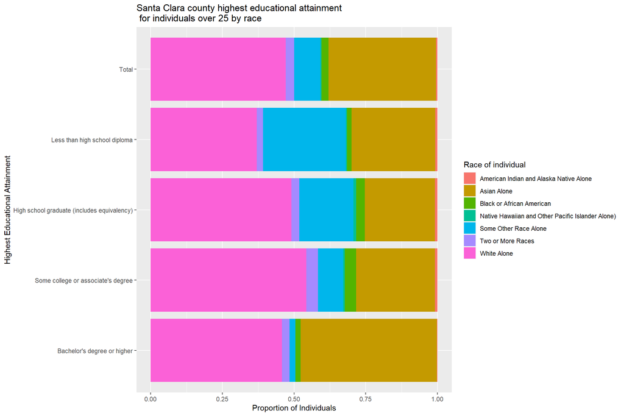

```r
scc_educ_attain_total <-
  scc_educ_attain_race %>%
  group_by(race) %>%
  summarize(estimate = sum(estimate)) %>%
  mutate(educattain = "Total")

scc_educ_attain_race %>%
  rbind(scc_educ_attain_total) %>%
  ggplot() +
  geom_bar(
    aes(
      x = educattain %>% factor(levels = rev(c("Total","Less than high school diploma","High school graduate (includes equivalency)","Some college or associate's degree","Bachelor's degree or higher"))),
      y = estimate,
      fill = race
    ),
    stat = "identity",
    position = "fill"
  ) +
  labs(
    x = "Highest Educational Attainment",
    y = "Proportion of Individuals",
    title = "Santa Clara county highest educational attainment \n for individuals over 25 by race",
    fill ="Race of individual"
  ) +
  coord_flip()
```

To begin answering the question of the pervasiveness of disproportionate education attainment by race in Santa Clara county for individuals over 25, we will refer to the filled bar chart. The first characteristic we point out is that individuals who are not White alone and not Asian alone hold a greater proportion of the “High school graduate” and “Less then high school diploma” than they do in the total population in Santa Clara. In the “Some college or associates degree” category, we see that individuals who are Asian alone show a lower percentage than they do in the total population, while White alone individuals show a higher proportion. However, the proportions are not dissimilar enough from the total population to draw clear conclusions from this bucket.

However, in the “Bachelor’s degree or higher” category, it is clear that individuals who are not White alone or Asian alone comprise a much smaller proportion than they do in the total population in Santa Clara. Likewise, individuals who are Asian alone comprise a much greater proportion of this category than in the total population in Santa Clara. Thus, in Santa Clara county we can conclude that individuals who are not White alone and not Asian alone comprise a higher proportion of people getting a high school degree or less, while the opposite is true of the proportion of people with a bachelor’s degree or higher. Hence, we do see a disproportionate education attainment by race in this county with respect to these observations.

Note that the education attainment of individuals under 25 who are no longer working towards a degree is unlikely to change the data significantly. The greatest change would likely be from individuals 18-25 who decided not to attend college. It would be an interesting extension to find the demographics of young adults who decided not to attend college, however they likely match the proportions in the chart above if we assume that trends hold over time.

Now, we will move on to estimate the number and percentage of K-12 students who have no internet access at home in Santa Clara county and the Bay Area as a whole.

First, we load in the variable data and search for the variables we care about. We find the we want ACCESS (access to the internet), SCHG (grade level attending), and PUMA (PUMS area code). Note that we are using the 2019 1 year data:

```r
census_api_key("2f12411b15b1fa77c7cf26406290bde11307de91")

pums_vars_2019 <-
  pums_variables %>%
  filter(year == 2019,survey == "acs1")

ca_pums <- get_pums(
  variables = c(
    "ACCESS",
    "SCHG",
    "PUMA"
  ),
  state = "CA",
  year = 2019,
  survey = "acs1",
  recode = T
)
```

Now we get filter to the PUMA’s in Santa Clara County and then in the Bay Area as a whole:

```r
santa_clara <-
  counties("CA",cb=T,progress_bar =F) %>%
  filter(NAME == "Santa Clara")

bay_county_names <-
  c(
    "Alameda",
    "Contra Costa",
    "Marin",
    "Napa",
    "San Francisco",
    "San Mateo",
    "Santa Clara",
    "Solano",
    "Sonoma"
  )

bay_counties <-
  counties("CA", cb = T, progress_bar = F) %>%
  filter(NAME %in% bay_county_names)

ca_pumas <-
  pumas("CA",cb = T,progress_bar = F)

sc_pumas <-
  ca_pumas %>%
  st_centroid() %>%
  .[santa_clara, ] %>%
  st_set_geometry(NULL) %>%
  left_join(ca_pumas %>% select(GEOID10)) %>%
  st_as_sf()

bay_pumas <-
  ca_pumas %>%
  st_centroid() %>%
  .[bay_counties, ] %>%
  st_set_geometry(NULL) %>%
  left_join(ca_pumas %>% select(GEOID10)) %>%
  st_as_sf()

sc_pums <-
  ca_pums %>%
  filter(PUMA %in% sc_pumas$PUMACE10)

bay_pums <-
  ca_pums %>%
  filter(PUMA %in% bay_pumas$PUMACE10)
```

Now we filter both PUMS sets to only include grade levels K-12 and remove N/A responses from internet access, which correspond to group quarters:

```r
schg_label <-
  2:14

access_label <-
  1:3

sc_pums_k12 <-
  sc_pums %>%
  filter(SCHG %in% schg_label, ACCESS %in% access_label)

bay_pums_k12 <-
  bay_pums %>%
  filter(SCHG  %in% schg_label,ACCESS %in% access_label)
```

Now we begin to calculate the percentage of k-12 students in Santa Clara County without access to internet:

```r
sc_pums_k12_int <-
  sc_pums_k12 %>%
  mutate(
    NOINTACCESS = ifelse(
      ACCESS == 3,
      PWGTP,
      0
    )
  )

perc_sc_noint <-
  sum(sc_pums_k12_int$NOINTACCESS)/sum(sc_pums_k12_int$PWGTP) *100

print(sum(sc_pums_k12_int$NOINTACCESS))
```

```
## [1] 2107
```

```r
print(perc_sc_noint)
```

```
## [1] 1.726568
```

Thus, we can estimate that about 2107 K-12 students in Santa Clara county do not have access to internet at home, which is roughly 1.72 percent.

For completeness, we compare this to the proportion across the Bay Area as a whole:

```r
bay_pums_k12_int <-
  bay_pums_k12 %>%
  mutate(
    NOINTACCESS = ifelse(
      ACCESS == 3,
      PWGTP,
      0
    )
  )

perc_bay_noint <-
  sum(bay_pums_k12_int$NOINTACCESS)/sum(bay_pums_k12_int$PWGTP) *100

print(sum(bay_pums_k12_int$NOINTACCESS))
```

```
## [1] 8386
```

```r
print(perc_bay_noint)
```

```
## [1] 1.848888
```

Across the Bay Area, the percentage of K-12 students without access to internet at home is roughly 1.84. We see that Santa Clara’s percentage is close to the average across the Bay Area, being slightly below.

No we plot the percentage of K-12 students without internet access for PUMAs in the bay area:

```r
bay_pums_k12_pumas <-
  bay_pums_k12_int %>%
  group_by(PUMA) %>%
  summarize(
    PERCNOINT = sum(NOINTACCESS)/sum(PWGTP) * 100
  ) %>%
  left_join(
    bay_pumas %>%
      select(PUMACE10),
    by = c("PUMA" = "PUMACE10")
  ) %>%
  st_as_sf()

pums_pal <- colorNumeric(
  palette = "Oranges",
  domain = bay_pums_k12_pumas$PERCNOINT
)

leaflet() %>%
  addTiles() %>%
  addPolygons(
    data = bay_pums_k12_pumas,
    fillColor = ~pums_pal(PERCNOINT),
    color = "white",
    opacity = 0.5,
    fillOpacity = 0.5,
    weight = 1,
    label = ~paste0(
      round(PERCNOINT),
      "% K-12 students without internet access"
    ),
    highlightOptions = highlightOptions(
      weight = 2,
      opacity = 1
    )
  ) %>%
  addLegend(
    data = bay_pums_k12_pumas,
    pal = pums_pal,
    values = ~PERCNOINT,
    title = "% K-12 students<br> without internet access"
  )
```

[interactive chart not shown]

We have that the highest percentage is roughly 10%, in a PUMA near Oakland.

So far, we have made no explicit analysis on what this data implies about remote learning during the pandemic. Taking the data at face value, one might conclude that less than 2 percent of K-12 students in the Bay Area do not have internet access, and thus the problem is localized to a few neighborhoods. However, this would be fallacious since that assumes that internet speed and reliability is the same throughout the Bay Area, which is certainly not true. Remote learning depends on a stable and sufficiently high internet speed, and the map gives no indication of these metrics. Thus, the proportion of K-12 students who have difficulty accessing remote learning is likely higher; based off this analysis we cannot say how much higher.

However, this map does give an indication of which neighborhoods are most affected with connectivity problems. Thus, we can take it as a measure of where to begin addressing connectivity issues. It will be interesting to compare these numbers to data released for 2020, as remote learning has certainly pushed communities to improve the internet access available to their residents.

Now, we do a migration analysis in Santa Clara county as a function of highest educational attainment.

```r
acs_vars_2019_1yr <-
    listCensusMetadata(
    name = "2019/acs/acs1",
    type = "variables"
  )
```

By searching the variables above, we find that the two groups we care about are B07009 and B07409 corresponding to geographical mobility by educational attainment for current residence and residence 1 year ago, respectively. Now, we first load in B07009:

```r
sc_mobility_current_19 <-
  getCensus(
    name = "acs/acs1",
    vintage = 2019,
    region = "county:085",
    regionin = "state:06",
    vars = c("group(B07009)")
  ) %>%
  select(!c(GEO_ID,state,NAME) & !ends_with(c("EA","MA","M"))) %>%
  pivot_longer(
    ends_with("E"),
    names_to = "variable",
    values_to = "estimate"
  ) %>%
  left_join(
    acs_vars_2019_1yr %>%
      select(name, label),
    by = c("variable" = "name")
  ) %>%
  select(-variable)
```

After examining the dataframe, we see that there is an aggregate total at the top, and after each subcategory there is a subtotal. Thus, we now know how to separate the data as follows:

```r
sc_mobility_current_19 <-
  getCensus(
    name = "acs/acs1",
    vintage = 2019,
    region = "county:085",
    regionin = "state:06",
    vars = c("group(B07009)")
  ) %>%
  select(!c(GEO_ID,state,NAME) & !ends_with(c("EA","MA","M"))) %>%
  pivot_longer(
    ends_with("E"),
    names_to = "variable",
    values_to = "estimate"
  ) %>%
  left_join(
    acs_vars_2019_1yr %>%
      select(name, label),
    by = c("variable" = "name")
  ) %>%
  select(-variable) %>%
  separate(
    label,
    into = c(NA,NA,"mobility","educattain"),
    sep = "!!"
  ) %>%
  mutate(
    mobility = ifelse(
      mobility %in% c("Same house 1 year ago:", "Moved within same county:"),
      "Here since last year",
      "Inflow"
    )
  ) %>%
  filter(!is.na(educattain)) %>%
  group_by(mobility,educattain) %>%
  summarize(estimate = sum(estimate))
```

Now we do the same for the 2019 dataset for residence 1 year ago:

```r
sc_mobility_lastyear_19 <-
  getCensus(
    name = "acs/acs1",
    vintage = 2019,
    region = "county:085",
    regionin = "state:06",
    vars = c("group(B07409)")
  ) %>%
  select(!c(GEO_ID,state,NAME) & !ends_with(c("EA","MA","M"))) %>%
  pivot_longer(
    ends_with("E"),
    names_to = "variable",
    values_to = "estimate"
  ) %>%
  left_join(
    acs_vars_2019_1yr %>%
      select(name, label),
    by = c("variable" = "name")
  ) %>%
  select(-variable)
```

Like before, we can now see which labels to keep and what to select to avoid double counting. Doing such parsing:

```r
sc_mobility_lastyear_19 <-
  getCensus(
    name = "acs/acs1",
    vintage = 2019,
    region = "county:085",
    regionin = "state:06",
    vars = c("group(B07409)")
  ) %>%
  select(!c(GEO_ID,state,NAME) & !ends_with(c("EA","MA","M"))) %>%
  pivot_longer(
    ends_with("E"),
    names_to = "variable",
    values_to = "estimate"
  ) %>%
  left_join(
    acs_vars_2019_1yr %>%
      select(name, label),
    by = c("variable" = "name")
  ) %>%
  select(-variable) %>%
  separate(
    label,
    into = c(NA,NA,"mobility","educattain"),
    sep = "!!"
  )  %>%
  mutate(
    mobility = ifelse(
      mobility %in% c("Same house:", "Moved within same county:"),
      "Here since last year",
      "Outflow"
    )
  ) %>%
  filter(!is.na(educattain)) %>%
  group_by(mobility,educattain)%>%
  summarize(estimate = sum(estimate))
```

Now, like the textbook, we want the total population in 2018. For this, we will use the B07009 group for 2018:

```r
sc_mobility_current_18 <-
  getCensus(
    name = "acs/acs1",
    vintage = 2018,
    region = "county:085",
    regionin = "state:06",
    vars = c("group(B07009)")
  ) %>%
  select(!c(GEO_ID,state,NAME) & !ends_with(c("EA","MA","M"))) %>%
  pivot_longer(
    ends_with("E"),
    names_to = "variable",
    values_to = "estimate"
  ) %>%
  left_join(
    acs_vars_2019_1yr %>%
      select(name, label),
    by = c("variable" = "name")
  ) %>%
  select(-variable) %>%
  separate(
    label,
    into = c(NA,NA,"mobility","educattain"),
    sep = "!!"
  ) %>%
  mutate(
    mobility = "Here last year"
  ) %>%
  filter(!is.na(educattain)) %>%
  group_by(mobility, educattain) %>%
  summarize(estimate = sum(estimate))
```

Now we again follow the textbooks lead and put these dataframes together, to get our ultimate Santa Clara county flow table by educational attainment:

```r
sc_flows_19 <-
  rbind(
    sc_mobility_current_18,
    sc_mobility_lastyear_19 %>%
      filter(mobility == "Outflow"),
    sc_mobility_current_19 %>%
      filter(mobility == "Inflow"),
    sc_mobility_current_19 %>%
      group_by(educattain) %>%
      summarize(estimate= sum(estimate)) %>%
      mutate(mobility = "Here this year")
  ) %>%
  pivot_wider(
    names_from = mobility,
    values_from = estimate
  ) %>%
    mutate(
    `External net` = Inflow - Outflow,
    `Internal net` = `Here this year` - `Here last year` - `External net`,
  ) %>%
    select(
    `Educational Attainment (>=25 years old)` = educattain,
    `Internal net`,
    `External net`,
    `Here last year`,
    `Here this year`,
    Outflow,
    Inflow
  )
```

Now note that our educational attainment labels are in a confusing order. We can fix this by specifying the order that we want:

```r
sc_flows_19 <-
  sc_flows_19 %>%
  slice(c(4,3,5,1,2))

knitr::kable(sc_flows_19)
```

| Educational Attainment (>=25 years old) | Internal net | External net | Here last year | Here this year | Outflow | Inflow |
| --- | --- | --- | --- | --- | --- | --- |
| Less than high school graduate | 3780 | -180 | 145290 | 148890 | 4696 | 4516 |
| High school graduate (includes equivalency) | 56 | 1123 | 184686 | 185865 | 6712 | 7835 |
| Some college or associate’s degree | 119 | -3394 | 293946 | 290671 | 11687 | 8293 |
| Bachelor’s degree | -4379 | -236 | 383232 | 378617 | 23263 | 23027 |
| Graduate or professional degree | -6143 | 10166 | 342615 | 346638 | 17414 | 27580 |